# Iniciación a R-base

## Funciones

Entender qué es una función y cómo “funciona una función” es muuuuy importante!!!

R y sus paquetes tienen muchísimas funciones que nos permiten, por ejemplo, calcular logaritmos, o raíces cuadradas, o calcular desviaciones típicas etc etc… Además, también podemos crear nuestras propias funciones. Seguramente crearemos algunas en el curso, pero antes, es MUY IMPORTANTE entender qué es y cómo “funciona”, cómo se usa, una función de R.

Repito, es muy importante entender qué es y cómo usar una función. De hecho, todo lo que ocurre/pasa en R es porque has llamado a una función. Si algo ocurre en R es porque has hecho una llamada a una función, una “function call”.

Una función no es más un trozo de código R, unas instrucciones de R, a las que les hemos puesto un nombre; entonces, cuando invoquemos ese nombre, esa función, se ejecutarán esas lineas de código.

Empecemos a usar alguna función sencilla (el objetivo es entender como “funciona” una función):

Una función muy sencilla es `sqrt()`. Como igual imagináis, la función `sqrt()` sirve para calcular la raíz cuadrada de un número. Alguien, ha escrito por nosotros unas lineas de código que sirven para hacer raíces cuadradas y ha asignado esas lineas de código al nombre `sqrt`. sqrt es el nombre de la función `sqrt()`

Como alguien se ha preocupado de construir una función para hacer raíces cuadradas, nosotros podemos usar esa función. Si por ejemplo queremos calcular la raíz cuadrada de 9, sólo tendremos que teclear en R `sqrt(9)`.

```r
sqrt(9)
```

```
#> [1] 3
```

Perfecto, está bien que sepamos como hacer raíces cuadradas en R, PERO **lo importante es empezar a entender la estructura de las funciones**.

La forma genérica de utilizar una función es algo como: `nombre_de_la_funcion(argumento_1, argumento_2, ....)`. En el caso de la función `sqrt()` su nombre es `sqrt` y esta función solo admite un argumento. Un vector de números[^4].

`sqrt()` solo admite un argumento, pero otras funciones pueden tener más de un argumento y quizás los argumentos no sean numéricos sino por ejemplo textuales. Buff!! es fácil, pero explicarlo por escrito, sin ver al que va a recibir la explicación, es complicado.

```r
sqrt(9)
sqrt(9, 4)   # no funciona porque sqrt() solo admite un argumento
sqrt("9")    # no funciona, solo hemos puesto un argumento pero es textual, y ha de ser numérico
```

Es decir, para usar una función tenemos que saber cuantos argumentos admite y de que tipo han de ser esos argumentos. Generalmente esto es obvio, pero habrá veces que tengamos que usar una función que no sepamos como funciona, entonces tendrás que buscar su ayuda.

Para obtener ayuda sobre una función podemos usar la función `help()`. Si tecleas en R `help(nombre_de_la_funcion)` se abrirá una ventana de ayuda en la pestaña “Help” del panel abajo-derecha. Probémoslo con la función `sqrt()`

```r
help(sqrt)
```

Al leer la ayuda de la función te darás cuenta que hace un rato hicimos un poco de trampas, ya que explicamos el funcionamiento de las funciones de una forma un poco simplificada. Vamos a hacerlo ahora mejor.

Yo dije que la estructura de una función es `nombre_de_la_funcion(argumento_1, argumento_2, ....)` cuando en realidad es : **`nombre_de_la_funcion(argumento_1 = valor_1, argumento_2 = valor_2, ....)`**.

Vamos a explicarlo con la función `sqrt()`. El nombre de la función `sqrt()` es `sqrt`; y ¿cuales son sus argumentos? Si miramos más detenidamente la ayuda, veremos que sí, que sólo tiene un argumento `x` , que además debe ser numérico.

Bien, pero ¿cual es el valor del argumento? Intenta descubrirlo con el chunk de código siguiente:

```r
sqrt(x = 9)
sqrt(x = 4)
```

La sintaxis correcta de `sqrt()` es efectivamente `nombre_de_la_funcion(argumento_1 = valor_1, argumento_2 = valor_2, ....)`, en su caso, como solo tiene un argumento: `sqrt(argumento = valor)`.

El nombre del argumento es `x`, y el valor del argumento es el que nosotros queramos, siempre que sea numérico. La sintaxis correcta-correcta es `sqrt(x = 9)`. 9 es el valor que le damos al argumento `x` de la función `sqrt()`.

Obviamente podemos cambiar el valor de la función, sino la función no nos sería muy útil. Entonces, ¿por qué funcionan las 2 lineas de código siguientes?

```r
sqrt(9)
```

```
#> [1] 3
```

```r
sqrt(4)
```

```
#> [1] 2
```

Pues porque a R no le importa que no pongas el nombre del argumento, puedes poner solamente su valor. Hablaremos de esto un poco más en clase.

A ver si consigues diferenciar, en una función, entre el nombre de un argumento y su valor

```r
x <- 25
sqrt(9)
```

```
#> [1] 3
```

```r
sqrt(x)
```

```
#> [1] 5
```

```r
sqrt(x = x)
```

```
#> [1] 5
```

Sí, cuesta un poco, poquet a poquet, [“bird by bird”](https://www.bookdepository.com/Bird-By-Bird-Anne-Lamott/9780385480017).

Otra vez más. Por favor, calculad con R el logaritmo de 1000 en base 10. Para ello tenéis que usar la función `log()`, y cómo no sabéis cómo se usa, no sabéis cómo es su sintaxis, no sabéis cuales son sus argumentos, os tocará mirar la ayuda de la función.

```r
help(log)
log(x = 1000, base = 10)
```

Al principio mirar la ayuda interna de R para las funciones abruma, pero muchas veces con mirar los ejemplos (que están siempre al final) o la sección de “Arguments” es suficiente. En el caso de `log()` vemos que admite dos argumentos, “x” y “base”. La ayuda nos dice que la sintaxis de la función es:

- log(x, base = exp(1))
- “x” ha de ser numérico (o complejo)
- “base” ha de ser un número positivo (o complejo)

Fíjate que la sintaxis de la función no es `log(x, base)`, sino `log(x, base = exp(1))`; esto indica que el argumento “base” tiene un valor asignado por defecto; es decir, si no especificamos el valor de “base”, “base” será exp(1); es decir, el numero e y estaremos tomando logaritmos naturales.

```r
log(1000)  #- como no especificamos el valor del argumento "base", R lo fija por defecto base = exp(1) y toma logaritmos naturales
```

```
#> [1] 6.907755
```

```r
log(1000, base = 10) #- ahora si estamos calculando logaritmo en base 10
```

```
#> [1] 3
```

Es más seguro poner los nombres de los argumentos, pero si no los pones, o solo los pones parcialmente, también funciona

```r
log(1000, bas = 10)   #- funciona, pero ...
```

```
#> [1] 3
```

```r
log(1000, 10)         #- esto sí es muy habitual verlo
```

```
#> [1] 3
```

Eso sí, si no pones el nombre de los argumentos, has de tener en cuenta el orden de estos.

```r
log(10, 1000)
```

```
#> [1] 0.3333333
```

Poco a poco iremos hablando más de funciones. Cuando usemos una nueva generalmente tendremos que consultar la **ayuda** para ver su sintaxis y sus argumentos.

Saber buscar ayuda es una de las habilidades más importantes a la hora de aprender a programar. [Este post](https://sctyner.github.io/rhelp.html) da buenos consejos sobre cómo buscar ayuda sobre R. En el siguiente apartado desarrollaré un poco la idea de cómo usar la ayuda interna de R sobre sus funciones.

### Ayuda de las funciones

Hay varias formas de pedir a R la ayuda interna de una función:

1. usando la función `help()`, o sea, tecleando en R `help(nombre_de_la_funcion)`; por ejemplo `help(log)`
2. tecleando en R `?nombre_de_la_funcion`; por ejemplo `?(log)`
3. la forma más cómoda, y la que suelo usar, consiste en situar el cursor en el nombre de la función y pulsar la tecla `F1`

Entender y saber leer la ayuda de las funciones es muy útil, así que os recomiendo, para más adelante (de momento tenemos otras cosas que aprender), la lectura de [este post](http://socviz.co/appendix.html#a-little-more-about-r). Explican bien como está estructurada la ayuda de las funciones. Abajo tienes un ejemplo con la función `mean()`.

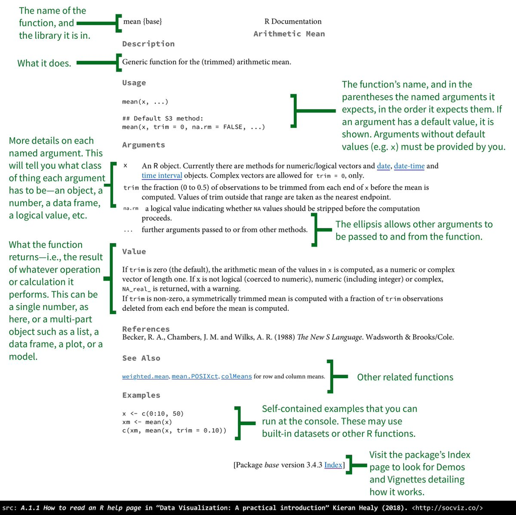

Cómo leer las ayudas de R (http://socviz.co/appendix.html#a-little-more-about-r)

Como ejemplo puedes probar a leer la ayuda de la función `seq()`. Mirando la ayuda intenta adivinar que harán las siguientes expresiones R. Tienes que entender porque la cuarta y quinta linea no devuelven el mismo resultado.

```r
seq(from = 0, to = 10)
```

```
#>  [1]  0  1  2  3  4  5  6  7  8  9 10
```

```r
seq(0, 10)
```

```
#>  [1]  0  1  2  3  4  5  6  7  8  9 10
```

```r
seq(10, 0)
```

```
#>  [1] 10  9  8  7  6  5  4  3  2  1  0
```

```r
seq(0, 10, 3)
```

```
#> [1] 0 3 6 9
```

```r
seq(0, 10, length.out = 3)
```

```
#> [1]  0  5 10
```

No solo tenemos la ayuda oficial, en R también hay funciones que nos pueden ayudar a entender como funciona otra función; por ejemplo la función `args()`, que como su nombre insinúa, nos permite ver los argumentos de una función. Por ejemplo:

```r
args(sqrt)       #- sqrt() solo tiene un argumento, x
args(log)        #- log() tiene 2 argumentos: x y base. Además base tiene un valor por defecto: exp(1)
args(args)       #- args() solo tiene un argumento, llamado name.
```

### Ciclo vital de las funciones

Otra idea que conviene conocer, es que las funciones tienen un ciclo vital o “life cycle”: hay funciones que acaban de ser creadas y aún son experimentales. Hay funciones que pueden estar siendo cuestionadas y otras que pasan de experimentales a estables. [Este post](https://www.tidyverse.org/lifecycle/) muestra los diferentes estados de una función. El estado actual de una función se suele conocer por su distintivo o “**badge**”. Por ejemplo, en el siguiente tweet se explica la diferencia entre una función cuyo badge es `deprecated` de otra función cuyo badge es `superseded`:

> Why [@hadleywickham](https://twitter.com/hadleywickham?ref_src=twsrc%5Etfw) and team switched from calling functions “retired” to “superseded” - “When people heard a function was retired they thought we were going to take it out back and shoot it in the head.” [#rstudioconf](https://twitter.com/hashtag/rstudioconf?src=hash&ref_src=twsrc%5Etfw) [pic.twitter.com/462hbOSkRv](https://t.co/462hbOSkRv)

> — Emily Robinson (@robinson_es) [January 30, 2020](https://twitter.com/robinson_es/status/1222972469650153472?ref_src=twsrc%5Etfw)

Ya vale de funciones, pero hay algo que a algunos os rondará por la cabeza.

Cuando hemos visto la ayuda de la función `sqrt()`, sólo tenía un argumento `x`, y este argumento tenía que ser, según la ayuda, un vector (o array[^5]) de números.

**PERO** nosotros no introdujimos un vector en `sqrt()`, sino que introdujimos un sólo número. Sí, es cierto, introdujimos un sólo número, pero R no entiende lo que es un escalar, para él un número aislado es un vector, para R el número 4 es un vector con un sólo elemento, el número 4.

Fíjate que el valor que introduzcamos en `sqrt()` tiene que cumplir dos requisitos, ser un vector y que sus valores sean numéricos. Estas dos ideas hay que tenerlas claras para trabajar con R:

- Tipos de datos: `sqrt()` sólo admite datos numéricos, pero ¿qué otros tipos de datos podemos utilizar en R? Lo hemos visto en una sección anterior (texto, lógicos,…) . Por ejemplo, si ejecutamos `sqrt("99")`, R nos devolverá un error, porque `"99"` no es numérico es texto.
- Estructuras de datos: El vector es una de las estructuras de datos que “entiende R”, una de las estructuras en las que puede almacenar datos y luego volver a encontrarlos, pero hay más (matrices, listas, data frames)

En la próxima sección se presentan las diferentes estructuras de datos que tiene R para almacenar datos, pero en el curso vamos a centrarnos principalmente en una estructura de datos, los datos tabulares, que en R se almacenan en una estructura llamada `data frame`.

En clase ya hemos trabajado con data.frames, es la estructura de datos a la que estamos más acostumbrados, una tabla de datos con filas y columnas. Son las típicas tablas de Excel, con las variables en columnas y las observaciones en filas. Es muy fácil e intuitivo porque estamos acostumbrados a ellas, es lo que estamos acostumbrados a trabajar en ciencias sociales.

Igual de intuitivo resulta el hecho de que hay variables numéricas, como por ejemplo el número de páginas de un libro, y variables cuyos valores son texto; por ejemplo el título o el autor del libro.

## Estructuras de datos en R

R es un lenguaje/programa/entorno para hacer estadística por lo que generalmente trabajaremos con datos. Pero los datos tienen que estar almacenados en objetos. Igual que en matemáticas podemos almacenar datos en determinadas estructuras como vectores o matrices, en R ocurre lo mismo, los datos se almacenan en objetos. PERO hay distintos tipos de objetos o estructuras de datos[^6].

Para almacenar conjuntos de valores o datos, R tiene definidas determinadas estructuras de datos. ¿Cuántas? ¿Cuáles? ¿Cómo se llaman?

Pues hay varias formas de contarlo, para Hadley Wickham sólo hay una estructura de datos, los vectores. Sólo que estos vectores pueden tener diversas propiedades. Hay vectores atómicos y vectores recursivos. Seguro que tiene razón, pero aunque sea un poco menos preciso, es mucho más útil explicarlo, al menos al principio, de otra forma.

Podemos pensar que las principales estructuras de datos en R son:

- vectores
- matrices
- arrays (matrices multidimensionales)
- listas
- data.frames

Las que más utilizaremos en el curso son los data.frames, y en segundo lugar las listas. Sí, pero en realidad estas 2 estructuras (data.frames y listas) son en realidad agrupaciones de vectores; es decir, la estructura básica, la más importante en R son los vectores. Son los más importantes porque el resto de estructuras se construyen a partir de grupos de vectores o añadiendo alguna propiedad adicional, o atributo, a un vector.

# 2. Vectores

La **estructura de datos fundamental en R es el vector**. En R, un vector es una estructura de datos que sirve para almacenar un conjunto ordenado de valores o elementos. Un vector puede contener cualquier número de elementos; sin embargo, **todos los elementos deben ser del mismo tipo**. Por ejemplo, un vector no puede contener números y texto.

Esta estructura para almacenar datos en R es muy fácil de entender porque son los típicos vectores que conocemos de matemáticas.

Vamos a crear nuestro primer vector en R; para ello usamos la función `c()`:

```r
aa <- c(3, 22, 6)
aa
```

```
#> [1]  3 22  6
```

Como vemos con la función `c()` hemos concatenado 3 números para construir un vector, el vector aa.

```r
is.vector(aa)
```

```
#> [1] TRUE
```

Una de las características que tiene esta estructura de datos es que los elementos de un vector tienen que ser todos del mismo tipo. En nuestro caso el vector `aa` tiene 3 elementos, todos ellos de tipo numérico, concretamente doubles. Veámoslo con `typeof()`

```r
typeof(aa)
```

```
#> [1] "double"
```

Creemos ahora un vector con datos textuales o caracteres:

```r
aa <- c("Hola", "número", "9")
is.vector(aa)
```

```
#> [1] TRUE
```

```r
typeof(aa)
```

```
#> [1] "character"
```

## Coerción

Ya dijimos que, en R, los elementos de un vector tienen que ser todos del mismo tipo; por eso decimos que los vectores son una estructura de datos homogénea.

Bien, pero ¿qué ocurre si en un vector hay elementos de distinto tipo?

por cómo están definidos internamente los vectores, sólo pueden contener elementos del mismo tipo, pero si por error introducimos valores de distinto tipo, R convertirá todos sus valores a un único tipo. Forzará a que sus elementos sean del mismo tipo. Esta forma de proceder en R, consistente en transformar todos los elementos de un vector a un mismo tipo se llama **coerción**.

¿A que tipo los convierte? Pues al menos flexible. Veámoslo con varios ejemplos:

```r
aa <- c(4, 6,  "Hola")
```

En la expresión de arriba hemos puesto en el vector `aa` tres elementos, 2 números y un string. No puede ser, estamos violando las reglas internas de R para los vectores: los vectores sólo pueden tener elementos del mismo tipo.

Entonces, ¿por qué R no nos devuelve un mensaje de error? Porque lo que hace es convertir los valores de `aa` a un único tipo, ¿a cual? veámoslo con `typeof()`.

```r
aa <- c(4, 6, "Hola")
is.vector(aa)
```

```
#> [1] TRUE
```

```r
typeof(aa)
```

```
#> [1] "character"
```

```r
aa               #- ¿qué ha pasado?
```

```
#> [1] "4"    "6"    "Hola"
```

Fíjate en los resultados. ha convertido los 2 números a caracteres. El primer elemento de `aa` no es el número cuatro sino el string 4. ¿Veis que está entre comillas? Lo ha convertido en el carácter `"4"`.

```r
aa <- c(TRUE, 4L, 4, "Hola")
typeof(aa)
```

```
#> [1] "character"
```

```r
aa <- c(TRUE, 4L, 4)
typeof(aa)
```

```
#> [1] "double"
```

```r
aa <- c(TRUE, 4L)
typeof(aa)
```

```
#> [1] "integer"
```

Fíjate que con el chunk de arriba puedes inferir las reglas de conversión que usa R. `character > double > integer > logical`. Si en el vector hay un valor de texto, todos los valores se convertirán al tipo character.

Los valores de tipo carácter son los menos flexibles, piensa que no hay ninguna forma de convertir “Hola” en un número o en boolean. Al contrario sí se puede: el número 9 siempre se puede convertir al carácter “9”. Los booleans (TRUE y FALSE) se pueden transformar tanto en texto como en numérico: TRUE pasará a ser 1 y FALSE = 0.

### Coerción explícita

A veces tendremos un vector de un tipo, por ejemplo numérico, pero nos gustaría convertirlo a por ejemplo character. ¿Podemos hacerlo? Sí.

```r
aa <- c(1:4)
aa
```

```
#> [1] 1 2 3 4
```

```r
aa <- as.character(aa)
aa
```

```
#> [1] "1" "2" "3" "4"
```

Hay toda una familia de unciones para hacer estas conversiones, si es que son posibles, ya que, por ejemplo, no podremos pasar un vector de strings a numérico.

```r
as.character()
as.logical()
as.numeric()
y algunas más como as.data.frame() ....
```

## Propiedades de los vectores

Todo vector tiene dos propiedades claves:

- su tipo, que podemos ver con `typeof()`
- su longitud, orden o número de elementos, que podemos ver con `length()`

```r
aa <- c(1:10)
typeof(aa)
```

```
#> [1] "integer"
```

```r
length(aa)
```

```
#> [1] 10
```

```r
attributes(aa)
```

Ademas, los vectores pueden tener más propiedades o [atributos](http://adv-r.had.co.nz/Data-structures.html#attributes). Estas propiedades son adicionales, no son necesarias y generalmente se usan para construir tipos especiales de vectores. Se definen los atributos con la función `attr()` y con `attributes()` se pueden ver los atributos que tiene un determinado vector.

```r
aa <- c(1:3)
attributes(aa)
```

```r
attr(aa, "atributo_1") <- "This is a vector"
attributes(aa)
```

```
#> $atributo_1
#> [1] "This is a vector"
```

```r
attr(aa, "atributo_2") <- c("primero", "segundo", "tercero")
aa
```

```
#> [1] 1 2 3
#> attr(,"atributo_1")
#> [1] "This is a vector"
#> attr(,"atributo_2")
#> [1] "primero" "segundo" "tercero"
```

Un atributo que a veces se usa es poner nombres a los elementos de un vector, se puede hacer directamente al crear el vector o después con `setNames()` o con `set_names()`

```r
aa <- c(a = 1, b = 2, c = 4)
```

```r
aa <- c(1,2,4)
aa <- setNames(aa, letters[1:3])
aa
```

```
#> a b c
#> 1 2 4
```

```r
aa <- c(1,2,4)
aa <- rlang::set_names(aa, c("a", "b", "c"))
aa
```

```
#> a b c
#> 1 2 4
```

## Subsetting con vectores

En R podemos agrupar valores en vectores. Perfecto, pero habrá veces que necesitemos manipular los vectores. Por ejemplo necesitaremos acceder a determinados elementos de un vector, quizás a los elementos que sean mayores que 5, o a los que empiecen con la letra A, etc etc… Este tipo de operaciones sobre los vectores se les conoce genéricamente como **subsetting**; porque lo que se hace es crear subconjuntos de un vector. Veámoslo.

Hay varios tipos de subsetting, pero con vectores los principales son 3:

1. **Positive Index**: podemos seleccionar por posición. Por ejemplo a los 2 primeros elementos o los 2 primeros y los 2 últimos. Veámoslo:

```r
aa <- c(10:1)
aa[c(1:2)]        #- primer y segundo elemento del vector
```

```
#> [1] 10  9
```

```r
aa[c(1,2,9,10)]   #- dos primeros y 2 últimos
```

```
#> [1] 10  9  2  1
```

```r
aa[c(1,1,10,10)]  #- si repites el indice se repite el elemento del vector
```

```
#> [1] 10 10  1  1
```

2. **Negative index**: eliminamos elementos del vector.

Por ejemplo eliminamos los 2 primeros elementos del vector y los 2 últimos:

```r
aa <- c(10:1)
aa[- c(1,2, 9:10)]
```

```
#> [1] 8 7 6 5 4 3
```

3. **Logical index**: se seleccionan aquellas posiciones marcadas con TRUE.

Esta forma de hacer subsetting será muy útil. De momento no lo apreciaremos, pero enseguida veremos su utilidad cuando hagamos subsetting lógico con funciones de comparación. Como ejemplo:

```r
aa <- 1:10
aa <- aa[aa >= 7]
aa
```

```
#> [1]  7  8  9 10
```

Si no acabas de entenderlo, corre las siguientes lineas de código:

```r
aa <- 1:10
aa <= 4
aa[aa <= 4]
aa <- aa[aa <= 4]
```

## Modificando elementos de un vector

```r
aa <- c(1:10)
aa[4] <- 88             #- el cuarto elemento de aa tomará el valor 88
aa <- c(aa, 111, 112)   #- añadimos 2 elementos al vector aa
```

Los vectores se pueden concatenar

```r
aa <- c(1:5)
bb <- c(100:105)
cc <- c(aa, bb)
```

## Creación de vectores mediante …

- secuencias
- repeticiones
- números aleatorios

### Secuencias

Ya sabemos que podemos generar secuencias de números con el operador `:`. Por ejemplo:

```r
1:10
```

```
#>  [1]  1  2  3  4  5  6  7  8  9 10
```

Pero la función `seq()` nos ofrecen más posibilidades:

```r
seq(1, 10, 2.5)
```

```
#> [1] 1.0 3.5 6.0 8.5
```

```r
seq(from = 1, to = 10, by = 2.5)
```

```
#> [1] 1.0 3.5 6.0 8.5
```

### Repeticiones

la función `rep()` permite generar vectores repitiendo los elementos de un vector o lista

```r
aa <- 1:3
rep(aa, 2)
```

```
#> [1] 1 2 3 1 2 3
```

```r
rep(aa, each = 2)
```

```
#> [1] 1 1 2 2 3 3
```

```r
rep(aa, c(2,2,4))
```

```
#> [1] 1 1 2 2 3 3 3 3
```

```r
rep(aa, each = 2, len = 10)
```

```
#>  [1] 1 1 2 2 3 3 1 1 2 2
```

```r
rep(aa, each = 2, times = 3)
```

```
#>  [1] 1 1 2 2 3 3 1 1 2 2 3 3 1 1 2 2 3 3
```

### generando números aleatorios

## Operaciones con vectores

Todos sabemos que los vectores se pueden sumar, multiplicar, trasponer, … En realidad en el curso no vamos a utilizar álgebra matricial o vectorial, pero si que vamos a manipular, a hacer operaciones con vectores, aunque generalmente lo haremos usando funciones.

No obstante, conviene saber algunas cosas sobre operaciones con vectores en R. Por ejemplo podemos sumar vectores:

```r
aa <- 1:10
bb <- 1:10
aa + bb
```

```
#>  [1]  2  4  6  8 10 12 14 16 18 20
```

### Recycling

Si intentamos hacer una operación con dos vectores pero estos no tienen el mismo orden, entonces R, automáticamente reciclará el vector más corto hasta que alcance la longitud del más grande y así poder hacer la operación. Este comportamiento se conoce como recycling. Por ejemplo:

Un ejemplo:

```r
aa <- 1:10
aa + 1
```

```
#>  [1]  2  3  4  5  6  7  8  9 10 11
```

Como es que hemos podido sumar `aa+1`, si son vectores de distinto orden. Pues porque R siempre intentará hacer la operación y si no se puede, lo que hace es **reciclar**, aumentar el vector más pequeño, ¿Cómo? Repitiendo los elementos del vector más pequeño hasta que alcance la longitud del vector más grande.

Otro ejemplo de reciclado:

```r
aa <- 1:6
bb <- 1:2
aa + bb
```

```
#> [1] 2 4 4 6 6 8
```

### funciones vectorizadas

La mayoría de funciones, y todos los operadores de R están vectorizados; es decir, si una función recibe como input un vector, se aplicará la función a cada uno de los elementos del vector.

Por ejemplo, la función `sqrt()` tiene un sólo argumento, admite como valor de su único argumento un vector de números[^7]. Se aplicará la función a cada uno de los elementos del vector:

```r
aa <- c(4, 9, 25)
sqrt(aa)
```

```
#> [1] 2 3 5
```

La vectorización de las funciones hace que R sea un lenguaje en la que no es muy frecuente el uso de for loops o bucles, ya que en realidad la vectorización implica que se está ejecutando un bucle interno, pues se aplica la función a cada uno de los elementos del vector.

No siempre, pero en general, en R se sustituyen los bucles `for` tanto por la vectorización como por el uso de una familia de funciones `*apply` o más recientemente con las funciones del paquete `purrr`.

## Operaciones de comparación

Los operadores de comparación también están vectorizados. Si comparamos 2 vectores, las comparaciones se efectúan elemento a elemento

```r
aa <- 1:3
bb <- 3:1

aa == bb
```

```
#> [1] FALSE  TRUE FALSE
```

```r
aa >= bb
```

```
#> [1] FALSE  TRUE  TRUE
```

```r
aa != bb
```

```
#> [1]  TRUE FALSE  TRUE
```

En las operaciones de comparación también aplica el recycling:

```r
aa <- 1:3
bb <- 2

aa == bb
```

```
#> [1] FALSE  TRUE FALSE
```

```r
aa >= bb
```

```
#> [1] FALSE  TRUE  TRUE
```

```r
aa != bb
```

```
#> [1]  TRUE FALSE  TRUE
```

## Operaciones de conjuntos

```r
aa <- 1:4
bb <- c(1:2, 99)

union(aa, bb)
```

```
#> [1]  1  2  3  4 99
```

```r
intersect(aa, bb)
```

```
#> [1] 1 2
```

```r
setdiff(aa, bb)       #- Elementos de aa que no están en bb
```

```
#> [1] 3 4
```

```r
setequal(aa,bb)       #- chequea si dos vectores son iguales
```

```
#> [1] FALSE
```

```r
setequal(1:4, 1:4)    #- chequea si dos vectores son iguales
```

```
#> [1] TRUE
```

## Funciones útiles con vectores

Hay muchísimas funciones que se pueden utilizar con vectores, pero algunas que merece la pena conocer son[^8] :

- `length()`: nos da el orden o número de elementos de un vector. Ya la vimos.

```r
aa <- 1:4
length(aa)
```

```
#> [1] 4
```

- `sum()`: devuelve la suma de los valores de un vector.

```r
aa <- 1:4
sum(aa)
```

```
#> [1] 10
```

¿Qué pasaría si el vector fue de tipo texto o character?

- `cumsum()`: devuelve un vector del mismo orden con la suma acumulada (hasta ese valor).

```r
aa <- 1:4
cumsum(aa)
```

```
#> [1]  1  3  6 10
```

- `mean()`: devuelve el valor de la media de los valores del vector.

```r
aa <- 1:4
mean(aa)
```

```
#> [1] 2.5
```

- `sort()`: devuelve un vector con los valores del vector original ordenados de menor a mayor

```r
aa <- c(2, 1, 4, 3)
sort(aa)
```

```
#> [1] 1 2 3 4
```

- `order()`: devuelve un vector con la posición que ocuparían los valores originales de un vector si se ordenasen de menor a mayor

```r
aa <- c(20, 10, 7, 30)
order(aa)
```

```
#> [1] 3 2 1 4
```

# 3. Matrices

Otra estructura para almacenar valores en R son las matrices. No las usaremos mucho, en realidad nada, pero conviene conocerlas un poco. R si que usa las matrices internamente por ejemplo para hacer análisis de regresión.

Al igual que los vectores, una matriz **sólo puede contener elementos del mismo tipo**, por eso decimos que es una estructura de datos de tipo homogénea.

```r
(aa <- matrix(1:6, ncol = 2, nrow = 3)) #- creamos una matriz 3x2
```

```
#>      [,1] [,2]
#> [1,]    1    4
#> [2,]    2    5
#> [3,]    3    6
```

Las matrices también se pueden crear **concatenando vectores**:

```r
aa <- c(1:3)
bb <- c(11:13)
cc <- cbind(aa, bb)  #- agrupamos los vectores por columnas con cbind()
dd <- rbind(aa, bb)  #- agrupamos los vectores por filas con rbinb()
```

## Subsetting con matrices

Es muy parecido al subsetting en vectores, el operador que usaremos es el mismo, `[ ]`, pero claro las matrices tienen dos dimensiones, usaremos `[ , ]`. Veámoslo:

```r
aa <- matrix(1:9, nrow = 3, ncol = 3) #- creamos una matriz 3x3

bb <- aa[2, 3]          #- seleccionamos el elemento (2,3) de la matriz

bb <- aa[ , 2]          #- seleccionamos la segunda columna (devuelve un vector)
bb <- aa[ , c(2,3)]     #- seleccionamos la segunda y tercera columna
bb <- aa[c(2,3), ]      #- seleccionamos la segunda y tercera FILAS

bb <- aa[-2, ]          #- eliminamos la segunda fila
bb <- aa[-2, -c(1,2)]   #- eliminamos la segunda fila y la primera y segunda Columnas
```

## Nombrar las filas y columnas

Al igual que los vectores, las matrices admiten atributos, entre ellos dar nombre a las filas y columnas

```r
aa <- matrix(1:6, nrow = 2, ncol = 3) #- creamos una matriz 2x3
aa
```

```
#>      [,1] [,2] [,3]
#> [1,]    1    3    5
#> [2,]    2    4    6
```

```r
colnames(aa) <- c("col_1", "col_2", "col_3")
rownames(aa) <- paste("fila", 1:2, sep = "_")
aa
```

```
#>        col_1 col_2 col_3
#> fila_1     1     3     5
#> fila_2     2     4     6
```

## Funciones para matrices

Hay muchas, por ejemplo:

```r
aa <- matrix(1:6, nrow = 3, ncol = 2)  #- matriz 3x2
dim(aa)  #- devuelve un vector con las dimensiones de la matriz
t(aa)    #- transpone la matriz
```

Por supuesto se pueden multiplicar matrices, calcular inversas etc etc…

# 4. Arrays

Otra estructura para almacenar valores en R son los arrays. Son matrices multidimensionales. No las usaremos mucho, en realidad nada. También es una estructura de datos homogénea; es decir, sus elementos tienen que ser todos del mismo tipo

```r
(aa <- array(1:12, c(2, 3, 2)) )
```

```
#> , , 1
#>
#>      [,1] [,2] [,3]
#> [1,]    1    3    5
#> [2,]    2    4    6
#>
#> , , 2
#>
#>      [,1] [,2] [,3]
#> [1,]    7    9   11
#> [2,]    8   10   12
```

Podéis imaginar que si tuviésemos que hacer subsetting de un array, tendríamos que utilizar `[ , , ]`. Por ejemplo

```r
aa[1, 2 , 1]
```

```
#> [1] 3
```

# 5. Factores

Podemos pensar que los factores son otro tipo de estructura para almacenar datos, aunque en realidad son vectores, pero vectores de un tipo especial. Veamos qué es un factor, para qué se utilizan, cómo puedo crearlos, etc…

Pues ya he dicho que los factores en realidad **SON VECTORES**, pero tienen un atributo que les hace comportarse de manera un poco especial.

Los creadores de R, crearon este tipo especial de vector llamado **factor** para almacenar información sobre **variables categóricas**; por ejemplo el color de ojos, o los días de la semana, los meses del año, el género etc…

En principio los factores sirven para representar variables categóricas: las categorías o valores que puede tomar la variable deberían ser fijas y conocidas. Por ejemplo, los días de la semana, que es una variable categórica con 7 categorías o grupos.

Mi opinión personal, puede que un poco extrema, es que los factores suelen dar problemas al manipular los datos, mejor evitarlos. Son útiles, sin embargo, al hacer gráficos (permiten ordenar las categorías para mostrarlas de la forma más conveniente) y cuando se trabaja con modelos estadísticos, ya que los factores se usan para representar variables categóricas, y las variables categóricas se incorporan, generalmente, en los modelos estadísticos mediante variables dummy. Si tienes tus variables categóricas almacenadas en factores las funciones relacionadas con los modelos, por ejemplo `lm()` tratarán la información de forma adecuada y generarán las dummies de forma automática en el modelo. Es muy fácil cometer errores al recodificar variables cuando codificas las variables categóricas como numéricas, así que mejor tenerlas como factores y que lo haga R por nosotros. Por ejemplo:

> Data scientists take note. Big JAMA paper retracted because treatment variable coded [1,2] recoded in error to [1,0]. Results of analysis reversed. Lung disease self-management program actually harmed patients. Check recoding carefully! via @themalariaareahttps://t.co/uF4bRLbqy8

> — Ewen Harrison (@ewenharrison) [October 13, 2019](https://twitter.com/ewenharrison/status/1183424510151872512?ref_src=twsrc%5Etfw)

En mi opinión, otra vez un poco extrema, el tidyverse comenzó como una lucha contra `string.as.factor = TRUE`[^9]. Afortunadamente, la próxima versión de R, la versión 4.0, tendrá la opción `string.as.factor` fijada a FALSE por defecto. El anuncio oficial se hizo en el post al que apunta este tweet:

> New R blog entry by Kurt Hornik: stringsAsFactorshttps://t.co/0h0rLvUWIQ

> — The R Foundation (@_R_Foundation) [February 17, 2020](https://twitter.com/_R_Foundation/status/1229386343995838465?ref_src=twsrc%5Etfw)

Ya dije que los factores se usan para representar variables categóricas y que pueden ser útiles cuando trabajas con gráficos, tablas y/o modelos estadísticos pero también son un poco raros/especiales[^10].

Si tienes que usar factores, es mejor que lo hagas con el package [`forcats`](https://forcats.tidyverse.org/). No lo he usado, pero el paquete [`questionr`](https://juba.github.io/questionr/articles/recoding_addins.html) tiene un adding para recodificar variables, entre ellos factores, en R.

Recodificar variables es una tarea muy común en análisis de datos y, a veces, suele ser fuente de errores. Por ejemplo, en [este post](https://www.datasurg.net/2019/10/15/jama-retraction-after-miscoding-new-finalfit-function-to-check-recoding/) nos cuentan un error en la recodificación de una variable que llevo a que un artículo tuviera que ser retirado. No se si el error de codificación llevó a errores en la vida real, pero el artículo analizaba tratamientos en pacientes hospitalizados.

### Creación de factores

Por ejemplo, podemos crear un vector de tipo character con 5 observaciones

```r
aa <- c("lunes", "martes", "jueves", "lunes", "martes")
aa
```

```
#> [1] "lunes"  "martes" "jueves" "lunes"  "martes"
```

De momento `aa` es un vector de texto. Si quisiéramos convertirlo a factor podríamos hacer lo siguiente:

```r
aa_factor <- as.factor(aa)
is.factor(aa_factor)
```

```
#> [1] TRUE
```

Sí, efectivamente, ahora `aa_factor` es un vector, sí, pero es un vector especial, es un un factor. Vamos a imprimirlo para ver si ha cambiado algo.

```r
aa_factor
```

```
#> [1] lunes  martes jueves lunes  martes
#> Levels: jueves lunes martes
```

Sí ahora al imprimir `aa_factor`, como es un factor, R nos ofrece más información. Un factor es un vector con atributos (con más información); en concreto un factor necesariamente tiene un atributo que son los `levels`, que nos indica cuantos grupos o categorías tiene el factor y cómo se llaman las categorías. En nuestro caso `aa_factor` tiene 3 levels o categorías.

```r
levels(aa_factor)
```

```
#> [1] "jueves" "lunes"  "martes"
```

Vuelvo a repetirlo. `aa_factor` es un factor, OK. Como es un factor, resulta que es un vector con un atributo especial, los `levels` (los grupos o categorías). En nuestro caso, `aa_factor` es un vector con 5 observaciones y 3 grupos/categorias/levels. No es tan complicado.

En realidad, los factores sí son un poco más raros de lo que he explicado. Por razones históricas, se trataba de ahorrar memoria en el ordenador, los `levels` (o niveles )se utilizan para mostrar la información, PERO internamente la información se almacena con un vector de enteros y eso a veces genera (o generaba) cosas digamos extrañas. No importa mucho si no lo entiendes del todo. Fíjate, los factores se muestran como texto pero en realidad internamente son enteros:

```r
aa_factor
```

```
#> [1] lunes  martes jueves lunes  martes
#> Levels: jueves lunes martes
```

```r
typeof(aa_factor)     #- internamente lo almacena como enteros !!
```

```
#> [1] "integer"
```

### El orden de los `levels`

El orden de los `levels` es importante, principalmente al hacer gráficos y tablas. Por defecto, R ordena los levels de forma alfabética y esto no siempre es adecuado. Veamos cual es el orden de los niveles en `aa_factor`

```r
levels(aa_factor)
```

```
#> [1] "jueves" "lunes"  "martes"
```

PERO hay funciones para reordenar los `levels`, por ejemplo:

```r
relevel(aa_factor, "martes")
```

```
#> [1] lunes  martes jueves lunes  martes
#> Levels: martes jueves lunes
```

También podemos crear el factor directamente:

```r
aa_factor_2 <- factor(aa, levels = c("lunes", "martes", "jueves"))
aa_factor_2
```

```
#> [1] lunes  martes jueves lunes  martes
#> Levels: lunes martes jueves
```

Aquí el orden de los levels lo hemos elegido nosotros. No hemos usado el orden alfabético sino el orden habitual en los días de la semana.

Ya dije que un factor es un vector con atributos. Veámoslo:

```r
aa <- 1:10
attributes(aa)
```

```r
aa_factor_2 <- factor(aa, levels = c("lunes", "martes", "jueves"))
attributes(aa_factor_2)
```

```
#> $levels
#> [1] "lunes"  "martes" "jueves"
#>
#> $class
#> [1] "factor"
```

El objeto `aa_factor_2` es un factor de R, aunque en el fondo no es más que un vector con atributos: los “levels” y “class”

### Más cosas sobre factores

Durante el curso trabajaremos con variables categóricas y, por tanto, usaremos factores. Para ello utilizaremos el paquete `forcats`. Si lo necesitáis seguro que encontráis tutoriales o cursos en la web, pero [aquí](https://rstatisticsblog.com/r-beginners/working-with-factors-in-r-tutorial-forcats-package/?utm_source=rss&utm_medium=rss&utm_campaign=working-with-factors-in-r-tutorial-forcats-package) tenéis uno de ellos; aunque quizás sea mejor acudir a la [web de `forcats`](https://forcats.tidyverse.org/).

Un buen resumen visual de qué son los factores es el siguiente mapa conceptual de [este repo](https://github.com/spcanelon/concept-maps):

[figure not shown]

Creado por Ildiko Czeller y Graham Parsons

# 6. Listas

Esta estructura de datos, aunque en realidad se construye por la agrupación de vectores, sí que se comporta de forma diferente a los vectores[^11]. Las listas son una estructura de datos heterogénea: sí que pueden contener elementos de distinto tipo.

La mejor forma de entender como funciona una lista es pensar que es como una cajonera. En cada cajón podemos poner diferentes cosas, encada cajón podemos poner objetos de diferentes tipos.

Para definir una lista se hace uso de la función `list()`. Creemos nuestra primera lista:

```r
# defino 3 vectores y una matriz
vec_numerico <- c(1:8)
vec_character <- c("Pedro", "Rebeca", "Susana")
vec_logic <- c(TRUE, FALSE, TRUE)
matriz <- matrix(1:6, nrow = 2, ncol = 3)

# creo una lista con cuatro elementos
my_list <- list(vec_numerico, vec_character, vec_logic, matriz)
my_list
```

```
#> [[1]]
#> [1] 1 2 3 4 5 6 7 8
#>
#> [[2]]
#> [1] "Pedro"  "Rebeca" "Susana"
#>
#> [[3]]
#> [1]  TRUE FALSE  TRUE
#>
#> [[4]]
#>      [,1] [,2] [,3]
#> [1,]    1    3    5
#> [2,]    2    4    6
```

Podemos crear la misma lista pero añadiendo nombres a los distintos elementos. Puede sernos útil a la hora de hacer subsetting en una lista.

```r
my_list <- list(slot_1 = vec_numerico, slot_2 = vec_character, slot_3 = vec_logic, slot_4 =matriz)
my_list
```

```
#> $slot_1
#> [1] 1 2 3 4 5 6 7 8
#>
#> $slot_2
#> [1] "Pedro"  "Rebeca" "Susana"
#>
#> $slot_3
#> [1]  TRUE FALSE  TRUE
#>
#> $slot_4
#>      [,1] [,2] [,3]
#> [1,]    1    3    5
#> [2,]    2    4    6
```

Las listas no tienen dimensiones tienen `length()`

```r
length(my_list) #- nuestra lista tiene 4 slots, 4 elementos
```

```
#> [1] 4
```

Las listas son sumamente flexibles porque un elemento de una lista puede ser otra lista.

```r
my_list_2 <- list(primer_slot = c(44:47), segundo_slot = my_list)
my_list_2
```

```
#> $primer_slot
#> [1] 44 45 46 47
#>
#> $segundo_slot
#> $segundo_slot$slot_1
#> [1] 1 2 3 4 5 6 7 8
#>
#> $segundo_slot$slot_2
#> [1] "Pedro"  "Rebeca" "Susana"
#>
#> $segundo_slot$slot_3
#> [1]  TRUE FALSE  TRUE
#>
#> $segundo_slot$slot_4
#>      [,1] [,2] [,3]
#> [1,]    1    3    5
#> [2,]    2    4    6
```

## Subsetting en listas

Como las listas son más complejas, tenemos más posibilidades para hacer subsetting.

Tendremos 3 operadores para hacer subsetting: `[`, `[[` y `$`.

- Empecemos con `[`. Si hacemos subsetting con `[` el objeto devuelto siempre será otra lista.

```r
my_list[2]  #- seleccionamos el segundo elemento de la lista. Nos devuelve una lista con un solo slot
```

```
#> $slot_2
#> [1] "Pedro"  "Rebeca" "Susana"
```

```r
my_list[c(2,3)]  #- seleccionamos el segundo y tercer elemento de la lista. Nos devuelve una lista con dos slots
```

```
#> $slot_2
#> [1] "Pedro"  "Rebeca" "Susana"
#>
#> $slot_3
#> [1]  TRUE FALSE  TRUE
```

- con `[` también se puede seleccionar por nombre

```r
my_list["slot_2"]  #- seleccionamos el segundo elemento de la lista. Nos devuelve una lista con un solo slot
```

```
#> $slot_2
#> [1] "Pedro"  "Rebeca" "Susana"
```

```r
my_list[c("slot_2", "slot_3")]  #- seleccionamos el segundo y tercer elemento de la lista. Nos devuelve una lista con dos slots
```

```
#> $slot_2
#> [1] "Pedro"  "Rebeca" "Susana"
#>
#> $slot_3
#> [1]  TRUE FALSE  TRUE
```

- subsetting listas con `[[`. **NO** devuelve una lista, nos devuelve el objeto que hay en el slot seleccionado

```r
my_list[[2]]  #- seleccionamos el segundo elemento de la lista. Nos devuelve el elemento que hay en el segundo slot; es decir un vector, vec_character
```

```
#> [1] "Pedro"  "Rebeca" "Susana"
```

- subsetting, por nombre, con `$`. No devuelve una lista, sino un elemento de la lista

```r
my_list$slot_4  #- seleccionamos el cuarto elemento de la lista, cuyo nombre es `slot_4`; es decir, nos devuelve una matriz.
```

```
#>      [,1] [,2] [,3]
#> [1,]    1    3    5
#> [2,]    2    4    6
```

- incluso se puede usar `[[` para hacer subsetting por nombre, si es que los elementos de la lista tienen nombre[^12]

```r
my_list[["slot_4"]]  #- seleccionamos el cuarto elemento de la lista, cuyo nombre es `slot_4`; es decir, nos devuelve una matriz.
```

```
#>      [,1] [,2] [,3]
#> [1,]    1    3    5
#> [2,]    2    4    6
```

Las listas se usan para muchas cosas; por ejemplo, para almacenar los resultados de la estimación de un modelo , etc…

Las listas son sumamente flexibles porque un elemento de una lista puede ser otra lista.

```r
my_list_2 <- list(primer_slot = c(44:47), segundo_slot = my_list)
my_list_2
```

```
#> $primer_slot
#> [1] 44 45 46 47
#>
#> $segundo_slot
#> $segundo_slot$slot_1
#> [1] 1 2 3 4 5 6 7 8
#>
#> $segundo_slot$slot_2
#> [1] "Pedro"  "Rebeca" "Susana"
#>
#> $segundo_slot$slot_3
#> [1]  TRUE FALSE  TRUE
#>
#> $segundo_slot$slot_4
#>      [,1] [,2] [,3]
#> [1,]    1    3    5
#> [2,]    2    4    6
```

¿Cómo podemos seleccionar la matriz que hay en my_list_2? Pues la matriz es uno de los cuatro elementos que hay en el segundo slot de my_list_2. Con `my_lis_2[[2]]` seleccionamos el segundo_slot, que es una lista (my_list), y en el cuarto slot de my_list esta la matriz. Así que podríamos hacerlo de varias maneras:

```r
my_list_2[[2]][[4]]
```

```
#>      [,1] [,2] [,3]
#> [1,]    1    3    5
#> [2,]    2    4    6
```

```r
my_list_2$segundo_slot$slot_4
```

```
#>      [,1] [,2] [,3]
#> [1,]    1    3    5
#> [2,]    2    4    6
```

Para terminar con las listas, [aquí](https://www.johndcook.com/blog/2015/12/02/r-lists-and-xml/) se explica visualmente la diferencia entre hacer subsetting con `[` y hacerlo con `[[`. Además se critica un poco a XML, un lenguaje de marcado que muchas veces se utiliza para almacenar e intercambiar datos.